# Visual patterns test analysis

### Models #2

Logistic mixed regression for the test phase. Does difference from prototypes or familiarity/novelty have an effect on correct categorization in the test phase?

These models use trial quality (familiar / novel) as a fixed effect only.

rt_resp is recognition test response, 0 stands for ‘old’ and 1 stands for ‘new’.

```
## Generalized linear mixed model fit by maximum likelihood (Laplace
##   Approximation) [glmerMod]
##  Family: binomial  ( logit )
## Formula: rt_resp ~ type * tq + (1 | workerId)
##    Data: tdlmm
##
##      AIC      BIC   logLik deviance df.resid
##   4055.5   4123.0  -2016.8   4033.5     3408
##
## Scaled residuals:
##     Min      1Q  Median      3Q     Max
## -5.6137 -0.8389  0.3913  0.7452  4.1089
##
## Random effects:
##  Groups   Name        Variance Std.Dev.
##  workerId (Intercept) 0.7169   0.8467
## Number of obs: 3419, groups:  workerId, 41
##
## Fixed effects:
##                      Estimate Std. Error z value Pr(>|z|)
## (Intercept)            1.2224     0.1880   6.501 7.95e-11 ***
## typesarr              -0.5723     0.1779  -3.217 0.001297 **
## typesarrcol           -0.9307     0.1755  -5.303 1.14e-07 ***
## typesarrsha           -1.4366     0.1768  -8.127 4.39e-16 ***
## typesarrshacol        -1.1741     0.1762  -6.663 2.69e-11 ***
## tqnew                  0.7707     0.2107   3.657 0.000255 ***
## typesarr:tqnew        -0.5040     0.2724  -1.850 0.064283 .
## typesarrcol:tqnew     -0.9582     0.2660  -3.603 0.000315 ***
## typesarrsha:tqnew     -0.7133     0.2684  -2.657 0.007875 **
## typesarrshacol:tqnew  -1.1954     0.2679  -4.462 8.12e-06 ***
## ---
## Signif. codes:  0 '***' 0.001 '**' 0.01 '*' 0.05 '.' 0.1 ' ' 1
##
## Correlation of Fixed Effects:
##             (Intr) typesrr typsrrc typesrrsh typsrrshc tqnew  typsrr:t typsrrc:
## typesarr    -0.529
## typesarrcol -0.538  0.567
## typesarrsha -0.536  0.563   0.573
## typesrrshcl -0.536  0.565   0.574   0.572
## tqnew       -0.446  0.470   0.475   0.471     0.473
## typsrr:tqnw  0.345 -0.652  -0.368  -0.365    -0.367    -0.773
## typsrrcl:tq  0.353 -0.372  -0.656  -0.373    -0.374    -0.793  0.613
## typsrrsh:tq  0.350 -0.369  -0.373  -0.652    -0.372    -0.785  0.607    0.622
## typsrrshcl:  0.350 -0.369  -0.374  -0.370    -0.653    -0.787  0.609    0.624
##             typsrrsh:t
## typesarr
## typesarrcol
## typesarrsha
## typesrrshcl
## tqnew
## typsrr:tqnw
## typsrrcl:tq
## typsrrsh:tq
## typsrrshcl:  0.618
## convergence code: 0
## Model failed to converge with max|grad| = 0.0046539 (tol = 0.002, component 1)
```

[output not shown]

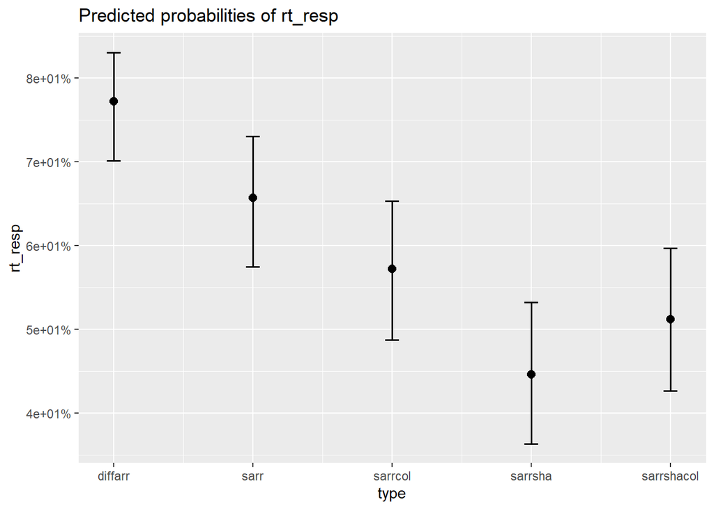

[output not shown]

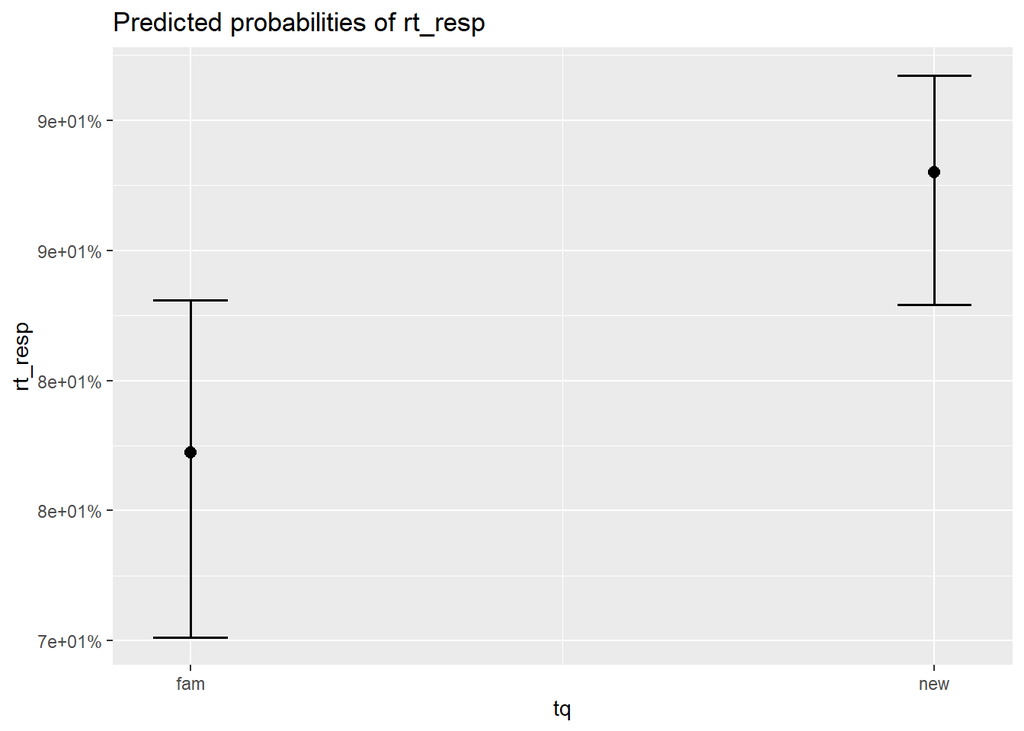

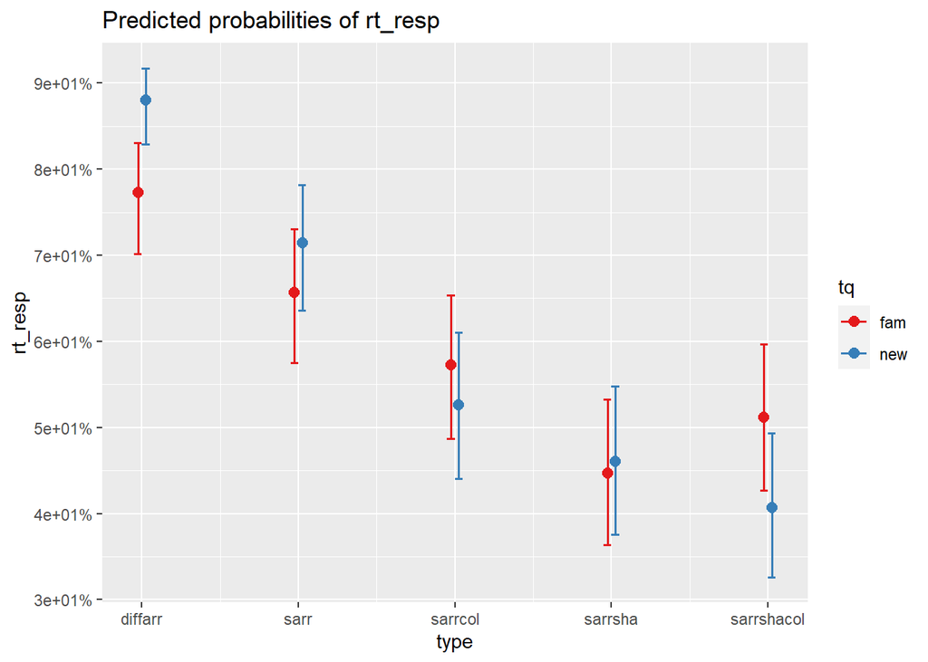

```
## Generalized linear mixed model fit by maximum likelihood (Laplace
##   Approximation) [glmerMod]
##  Family: binomial  ( logit )
## Formula: rt_resp ~ DTF * tq + (1 | workerId)
##    Data: tdlmm
##
##      AIC      BIC   logLik deviance df.resid
##   4087.1   4117.8  -2038.5   4077.1     3414
##
## Scaled residuals:
##     Min      1Q  Median      3Q     Max
## -5.2303 -0.8918  0.3998  0.7701  5.0830
##
## Random effects:
##  Groups   Name        Variance Std.Dev.
##  workerId (Intercept) 0.7082   0.8416
## Number of obs: 3419, groups:  workerId, 41
##
## Fixed effects:
##             Estimate Std. Error z value Pr(>|z|)
## (Intercept) -0.19213    0.15770  -1.218  0.22312
## DTF          0.08691    0.01106   7.860 3.84e-15 ***
## tqnew       -0.43992    0.12994  -3.386  0.00071 ***
## DTF:tqnew    0.07412    0.01750   4.235 2.29e-05 ***
## ---
## Signif. codes:  0 '***' 0.001 '**' 0.01 '*' 0.05 '.' 0.1 ' ' 1
##
## Correlation of Fixed Effects:
##           (Intr) DTF    tqnew
## DTF       -0.435
## tqnew     -0.363  0.523
## DTF:tqnew  0.270 -0.624 -0.807
```

[output not shown]

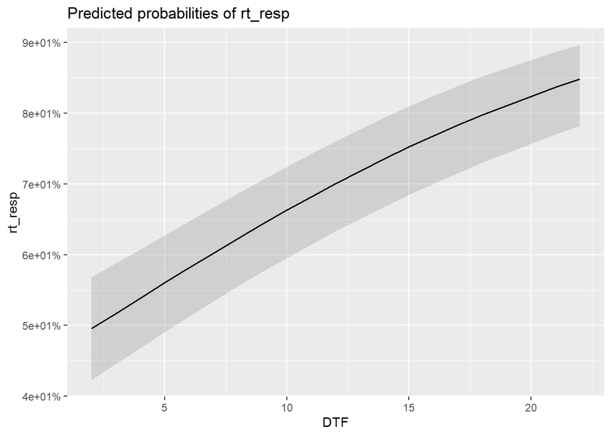

[output not shown]

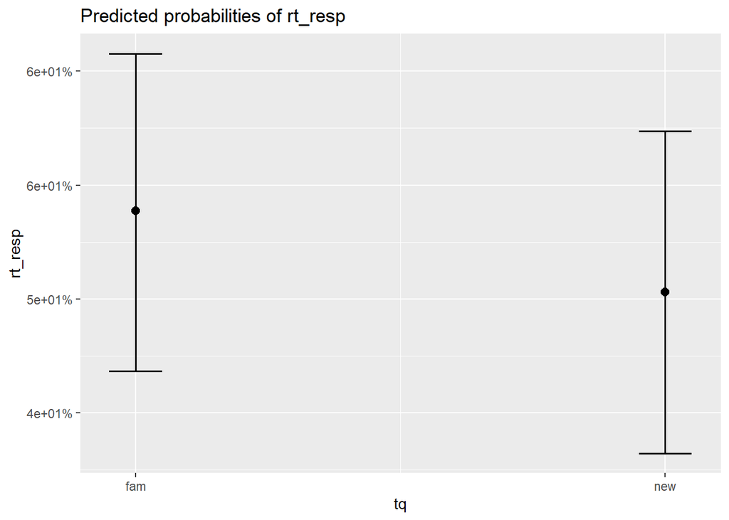

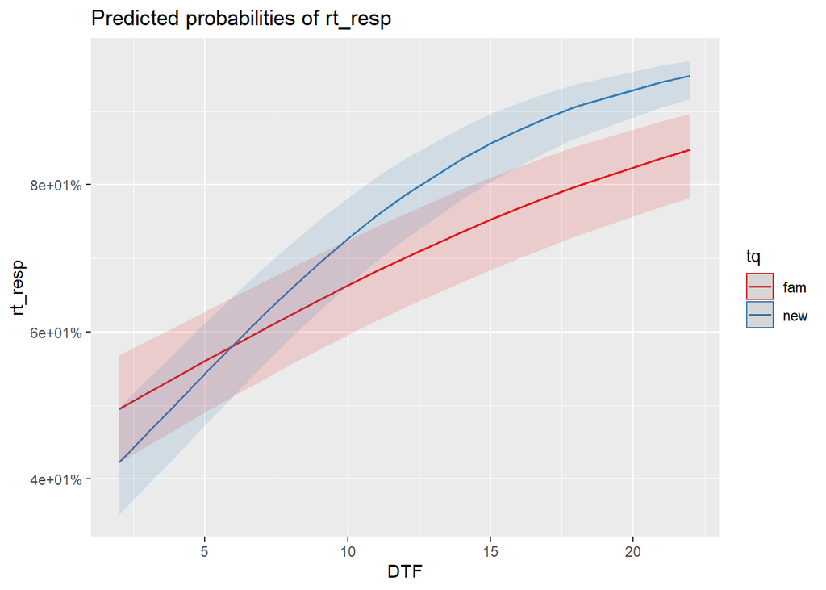

```
## Generalized linear mixed model fit by maximum likelihood (Laplace
##   Approximation) [glmerMod]
##  Family: binomial  ( logit )
## Formula: rt_resp ~ DTAF * tq + (1 | workerId)
##    Data: tdlmm
##
##      AIC      BIC   logLik deviance df.resid
##   4100.3   4130.9  -2045.1   4090.3     3414
##
## Scaled residuals:
##     Min      1Q  Median      3Q     Max
## -4.6894 -0.8860  0.4150  0.7783  4.1188
##
## Random effects:
##  Groups   Name        Variance Std.Dev.
##  workerId (Intercept) 0.6892   0.8302
## Number of obs: 3419, groups:  workerId, 41
##
## Fixed effects:
##             Estimate Std. Error z value Pr(>|z|)
## (Intercept) -1.70467    0.29144  -5.849 4.94e-09 ***
## DTAF         0.16315    0.02030   8.036 9.25e-16 ***
## tqnew       -1.32992    0.39229  -3.390 0.000699 ***
## DTAF:tqnew   0.10722    0.03077   3.485 0.000492 ***
## ---
## Signif. codes:  0 '***' 0.001 '**' 0.01 '*' 0.05 '.' 0.1 ' ' 1
##
## Correlation of Fixed Effects:
##            (Intr) DTAF   tqnew
## DTAF       -0.876
## tqnew      -0.590  0.646
## DTAF:tqnew  0.573 -0.654 -0.981
```

[output not shown]

```
## Data were 'prettified'. Consider using `terms="DTAF [all]"` to get smooth plots.
```

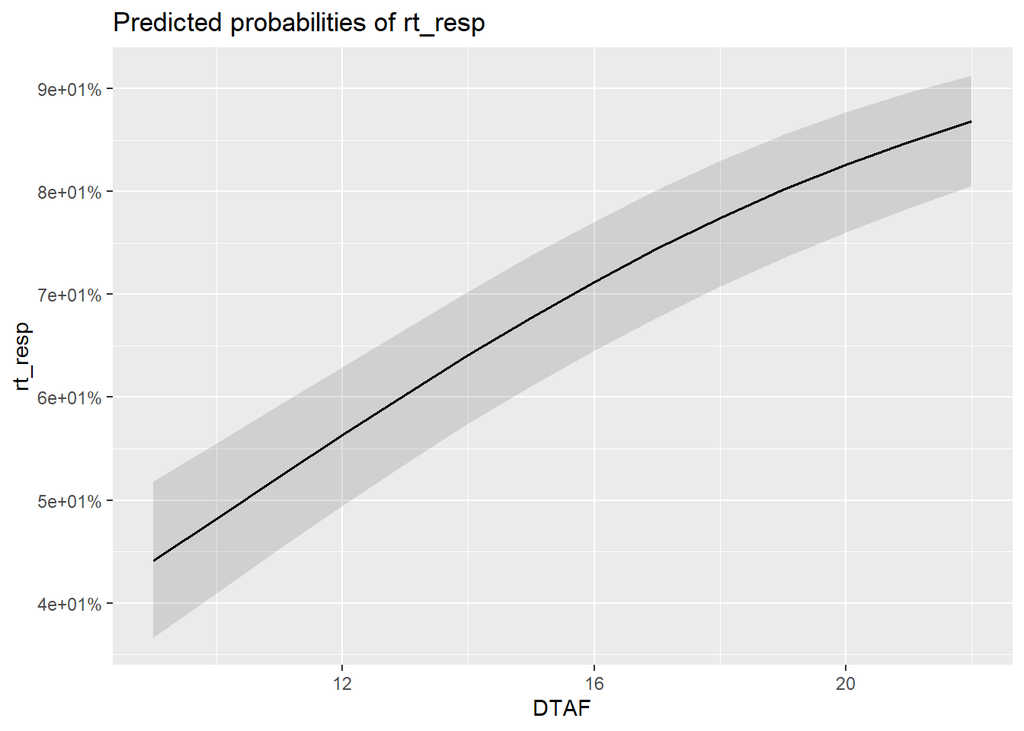

[output not shown]

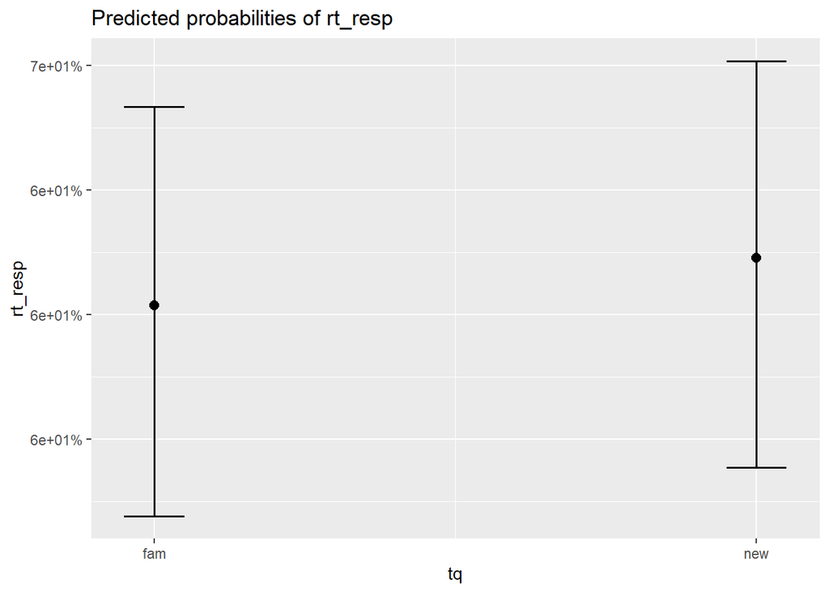

```
## Data were 'prettified'. Consider using `terms="DTAF [all]"` to get smooth plots.
```

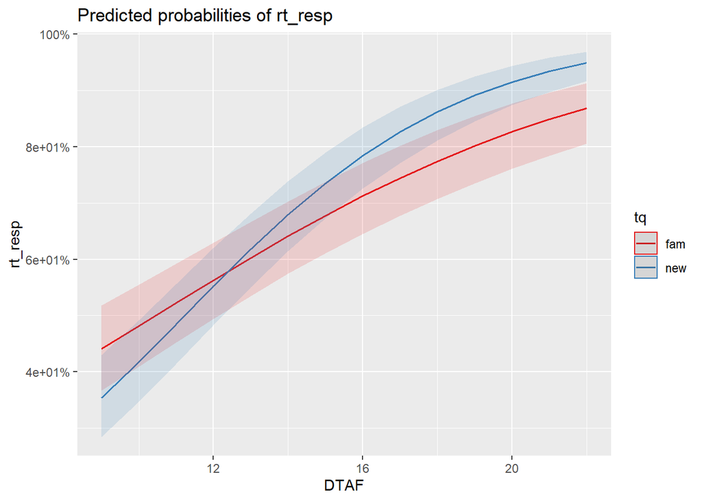

```
## Generalized linear mixed model fit by maximum likelihood (Laplace
##   Approximation) [glmerMod]
##  Family: binomial  ( logit )
## Formula: rt_resp ~ DTAN * tq + (1 | workerId)
##    Data: tdlmm
##
##      AIC      BIC   logLik deviance df.resid
##   4139.5   4170.2  -2064.7   4129.5     3414
##
## Scaled residuals:
##     Min      1Q  Median      3Q     Max
## -6.2950 -0.8987  0.4395  0.7650  3.5613
##
## Random effects:
##  Groups   Name        Variance Std.Dev.
##  workerId (Intercept) 0.6712   0.8193
## Number of obs: 3419, groups:  workerId, 41
##
## Fixed effects:
##             Estimate Std. Error z value Pr(>|z|)
## (Intercept) -2.53753    0.39847  -6.368 1.91e-10 ***
## DTAN         0.22890    0.02952   7.754 8.87e-15 ***
## tqnew       -1.59518    0.55391  -2.880  0.00398 **
## DTAN:tqnew   0.12994    0.04352   2.986  0.00283 **
## ---
## Signif. codes:  0 '***' 0.001 '**' 0.01 '*' 0.05 '.' 0.1 ' ' 1
##
## Correlation of Fixed Effects:
##            (Intr) DTAN   tqnew
## DTAN       -0.937
## tqnew      -0.641  0.670
## DTAN:tqnew  0.631 -0.673 -0.991
```

[output not shown]

```
## Data were 'prettified'. Consider using `terms="DTAN [all]"` to get smooth plots.
```

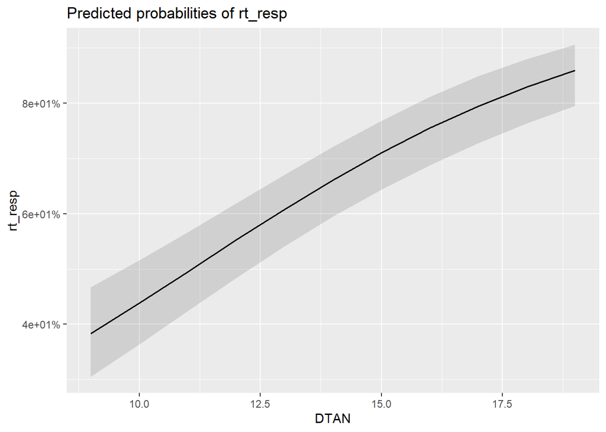

[output not shown]

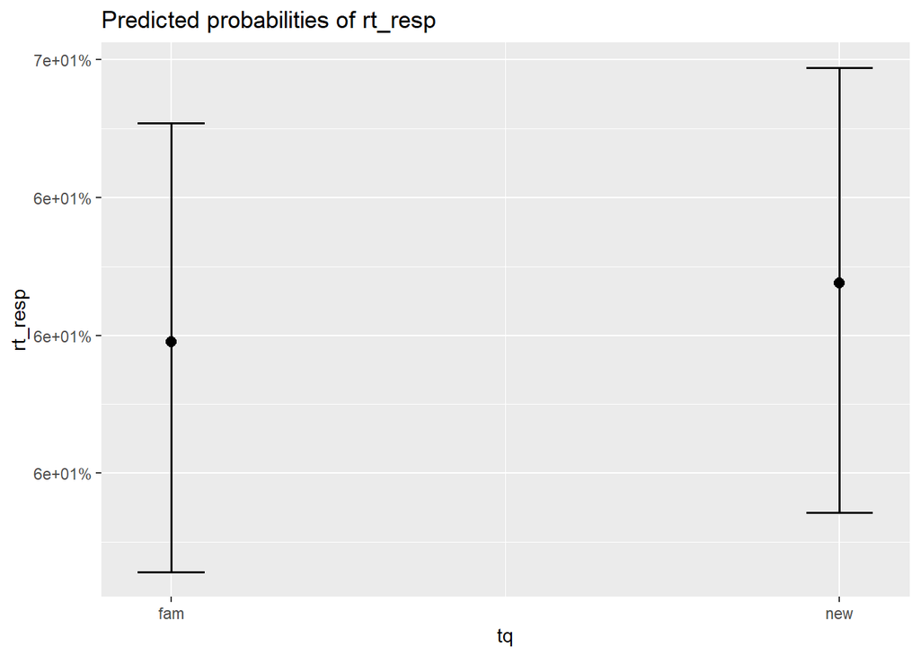

```
## Data were 'prettified'. Consider using `terms="DTAN [all]"` to get smooth plots.
```

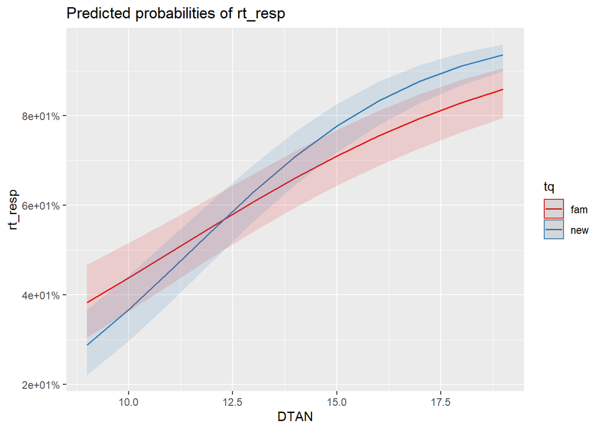

```
## Generalized linear mixed model fit by maximum likelihood (Laplace
##   Approximation) [glmerMod]
##  Family: binomial  ( logit )
## Formula: rt_resp ~ DTN_byPhase * tq + (1 | workerId)
##    Data: tdlmm
##
##      AIC      BIC   logLik deviance df.resid
##   4158.0   4188.6  -2074.0   4148.0     3414
##
## Scaled residuals:
##     Min      1Q  Median      3Q     Max
## -5.5239 -0.9069  0.4421  0.7664  3.5134
##
## Random effects:
##  Groups   Name        Variance Std.Dev.
##  workerId (Intercept) 0.6642   0.815
## Number of obs: 3419, groups:  workerId, 41
##
## Fixed effects:
##                   Estimate Std. Error z value Pr(>|z|)
## (Intercept)       -2.51049    0.40737  -6.163 7.15e-10 ***
## DTN_byPhase        0.21893    0.02922   7.493 6.75e-14 ***
## tqnew             -1.46914    0.56295  -2.610  0.00906 **
## DTN_byPhase:tqnew  0.11514    0.04262   2.701  0.00690 **
## ---
## Signif. codes:  0 '***' 0.001 '**' 0.01 '*' 0.05 '.' 0.1 ' ' 1
##
## Correlation of Fixed Effects:
##             (Intr) DTN_bP tqnew
## DTN_byPhase -0.941
## tqnew       -0.649  0.677
## DTN_byPhs:t  0.641 -0.681 -0.991
```

[output not shown]

```
## Data were 'prettified'. Consider using `terms="DTN_byPhase [all]"` to get smooth plots.
```

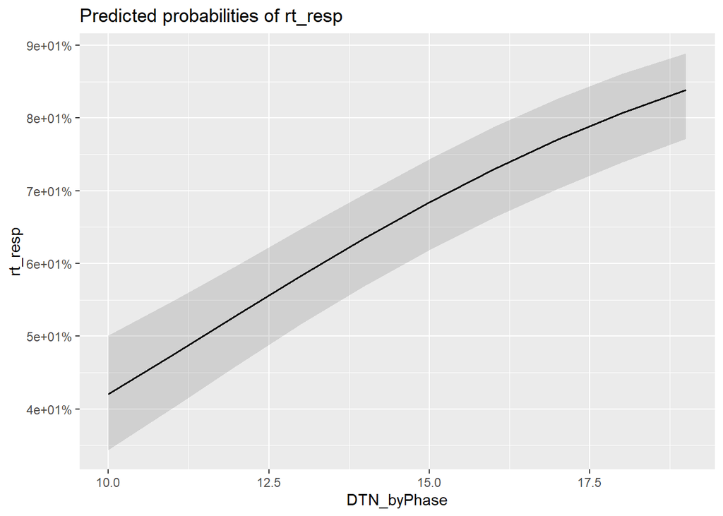

[output not shown]

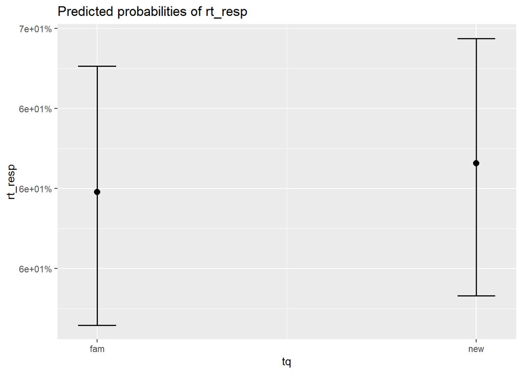

```
## Data were 'prettified'. Consider using `terms="DTN_byPhase [all]"` to get smooth plots.
```

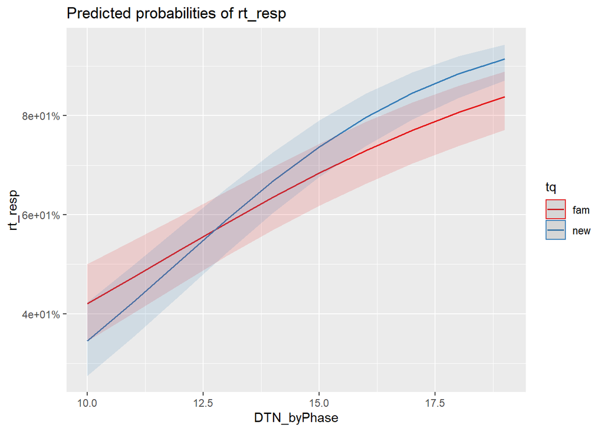

```
## Generalized linear mixed model fit by maximum likelihood (Laplace
##   Approximation) [glmerMod]
##  Family: binomial  ( logit )
## Formula: rt_resp ~ DTPPm * tq + (1 | workerId)
##    Data: tdlmm
##
##      AIC      BIC   logLik deviance df.resid
##   4090.7   4121.4  -2040.4   4080.7     3414
##
## Scaled residuals:
##     Min      1Q  Median      3Q     Max
## -5.0525 -0.8785  0.4117  0.7795  4.1482
##
## Random effects:
##  Groups   Name        Variance Std.Dev.
##  workerId (Intercept) 0.692    0.8319
## Number of obs: 3419, groups:  workerId, 41
##
## Fixed effects:
##             Estimate Std. Error z value Pr(>|z|)
## (Intercept) -2.74510    0.38804  -7.074  1.5e-12 ***
## DTPPm        0.23071    0.02701   8.540  < 2e-16 ***
## tqnew       -1.63673    0.54842  -2.984  0.00284 **
## DTPPm:tqnew  0.12298    0.04066   3.024  0.00249 **
## ---
## Signif. codes:  0 '***' 0.001 '**' 0.01 '*' 0.05 '.' 0.1 ' ' 1
##
## Correlation of Fixed Effects:
##             (Intr) DTPPm  tqnew
## DTPPm       -0.932
## tqnew       -0.622  0.654
## DTPPm:tqnew  0.613 -0.658 -0.990
## convergence code: 0
## Model failed to converge with max|grad| = 0.00419581 (tol = 0.002, component 1)
```

[output not shown]

```
## Data were 'prettified'. Consider using `terms="DTPPm [all]"` to get smooth plots.
```

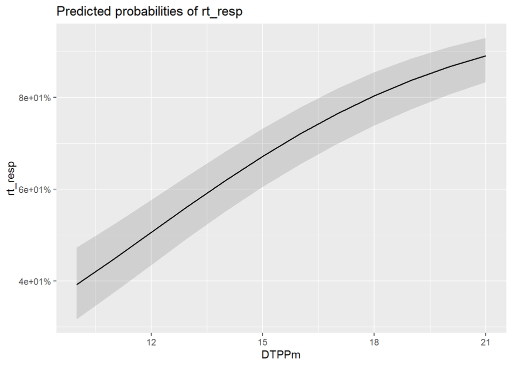

[output not shown]

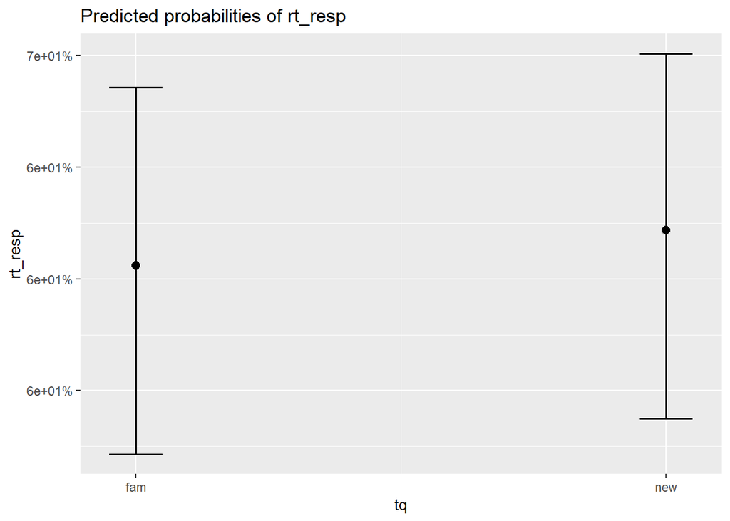

```
## Data were 'prettified'. Consider using `terms="DTPPm [all]"` to get smooth plots.
```

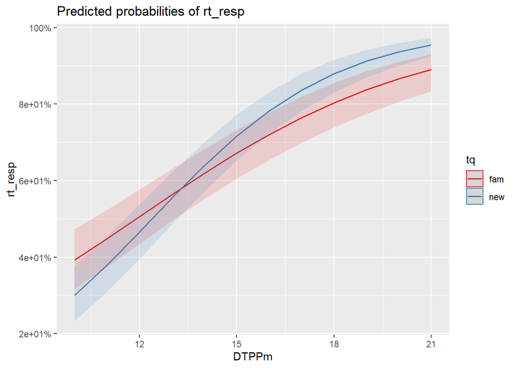

[output not shown]

## Test phase and study response

## Test phase

### Models #1

Logistic mixed regression for the test phase. Does difference from prototypes or familiarity/novelty have an effect on correct categorization in the test phase?

rt_resp is recognition test response, 0 stands for ‘old’ and 1 stands for ‘new’.

```
## Generalized linear mixed model fit by maximum likelihood (Laplace
##   Approximation) [glmerMod]
##  Family: binomial  ( logit )
## Formula: rt_resp ~ type * st_corr + (1 | workerId)
##    Data: t2lmm
##
##      AIC      BIC   logLik deviance df.resid
##   2146.9   2206.9  -1062.4   2124.9     1723
##
## Scaled residuals:
##     Min      1Q  Median      3Q     Max
## -3.3631 -0.9378  0.4700  0.7403  2.5356
##
## Random effects:
##  Groups   Name        Variance Std.Dev.
##  workerId (Intercept) 0.5009   0.7077
## Number of obs: 1734, groups:  workerId, 41
##
## Fixed effects:
##                         Estimate Std. Error z value Pr(>|z|)
## (Intercept)             1.201485   0.345511   3.477 0.000506 ***
## typesarr               -0.958669   0.387895  -2.471 0.013456 *
## typesarrcol            -1.330754   0.391533  -3.399 0.000677 ***
## typesarrsha            -2.308420   0.388506  -5.942 2.82e-09 ***
## typesarrshacol         -1.562315   0.401699  -3.889 0.000101 ***
## st_corr                -0.001504   0.358268  -0.004 0.996651
## typesarr:st_corr        0.570676   0.437436   1.305 0.192032
## typesarrcol:st_corr     0.584108   0.438650   1.332 0.182991
## typesarrsha:st_corr     1.418650   0.440299   3.222 0.001273 **
## typesarrshacol:st_corr  0.547445   0.447155   1.224 0.220844
## ---
## Signif. codes:  0 '***' 0.001 '**' 0.01 '*' 0.05 '.' 0.1 ' ' 1
##
## Correlation of Fixed Effects:
##             (Intr) typesrr typsrrc typesrrsh typsrrshc st_crr typsrr:s_
## typesarr    -0.788
## typesarrcol -0.787  0.695
## typesarrsha -0.799  0.703   0.702
## typesrrshcl -0.765  0.676   0.672   0.682
## st_corr     -0.867  0.760   0.761   0.770     0.739
## typsrr:st_c  0.696 -0.887  -0.615  -0.622    -0.598    -0.803
## typsrrcl:s_  0.702 -0.620  -0.894  -0.625    -0.599    -0.810  0.657
## typsrrsh:s_  0.704 -0.621  -0.619  -0.883    -0.602    -0.809  0.657
## typsrrshc:_  0.686 -0.607  -0.602  -0.611    -0.899    -0.791  0.643
##             typsrrc:_ typsrrsh:s_
## typesarr
## typesarrcol
## typesarrsha
## typesrrshcl
## st_corr
## typsrr:st_c
## typsrrcl:s_
## typsrrsh:s_  0.658
## typsrrshc:_  0.642     0.644
## convergence code: 0
## Model failed to converge with max|grad| = 0.00290642 (tol = 0.002, component 1)
```

[output not shown]

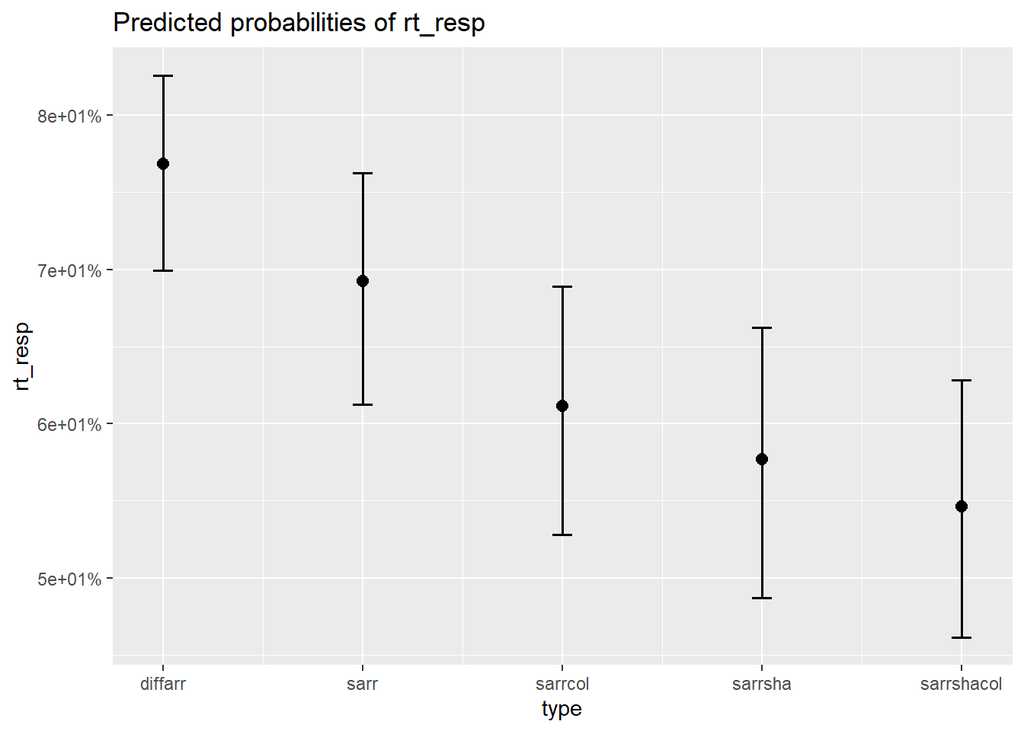

[output not shown]

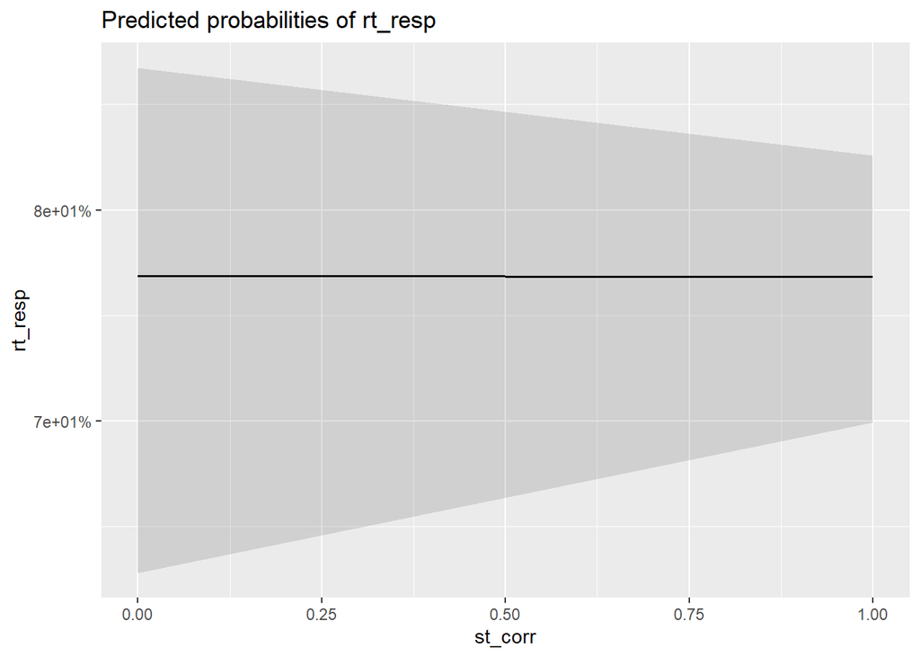

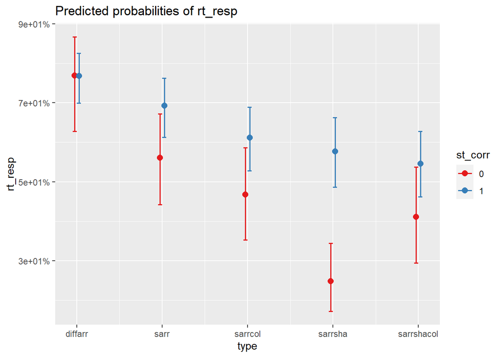

```
## Generalized linear mixed model fit by maximum likelihood (Laplace
##   Approximation) [glmerMod]
##  Family: binomial  ( logit )
## Formula: rt_resp ~ DTF * st_corr + (1 | workerId)
##    Data: t2lmm
##
##      AIC      BIC   logLik deviance df.resid
##   2154.6   2181.9  -1072.3   2144.6     1729
##
## Scaled residuals:
##     Min      1Q  Median      3Q     Max
## -3.7956 -0.9423  0.4861  0.7682  2.6612
##
## Random effects:
##  Groups   Name        Variance Std.Dev.
##  workerId (Intercept) 0.4812   0.6937
## Number of obs: 1734, groups:  workerId, 41
##
## Fixed effects:
##             Estimate Std. Error z value Pr(>|z|)
## (Intercept) -0.99464    0.20721  -4.800 1.59e-06 ***
## DTF          0.14155    0.02694   5.254 1.49e-07 ***
## st_corr      1.15281    0.20506   5.622 1.89e-08 ***
## DTF:st_corr -0.07886    0.02950  -2.673  0.00751 **
## ---
## Signif. codes:  0 '***' 0.001 '**' 0.01 '*' 0.05 '.' 0.1 ' ' 1
##
## Correlation of Fixed Effects:
##             (Intr) DTF    st_crr
## DTF         -0.688
## st_corr     -0.737  0.690
## DTF:st_corr  0.629 -0.912 -0.792
```

[output not shown]

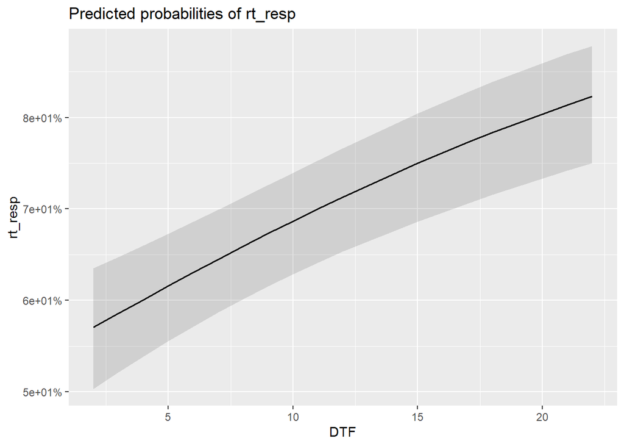

[output not shown]

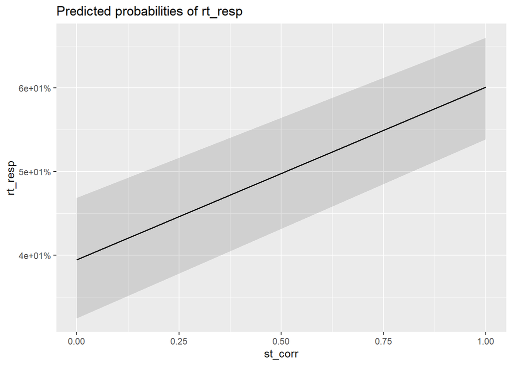

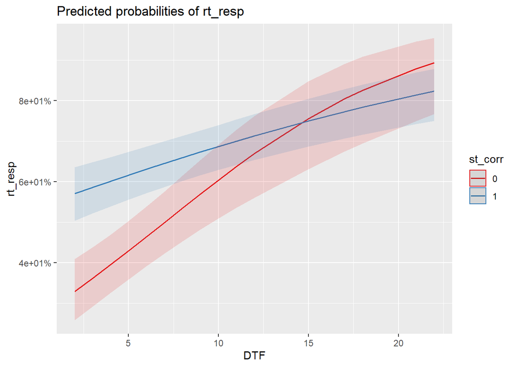

```
## Generalized linear mixed model fit by maximum likelihood (Laplace
##   Approximation) [glmerMod]
##  Family: binomial  ( logit )
## Formula: rt_resp ~ DTAF * st_corr + (1 | workerId)
##    Data: t2lmm
##
##      AIC      BIC   logLik deviance df.resid
##   2160.0   2187.3  -1075.0   2150.0     1729
##
## Scaled residuals:
##     Min      1Q  Median      3Q     Max
## -3.4730 -0.9468  0.4775  0.7676  2.5020
##
## Random effects:
##  Groups   Name        Variance Std.Dev.
##  workerId (Intercept) 0.465    0.6819
## Number of obs: 1734, groups:  workerId, 41
##
## Fixed effects:
##              Estimate Std. Error z value Pr(>|z|)
## (Intercept)  -2.51080    0.54913  -4.572 4.82e-06 ***
## DTAF          0.18877    0.04356   4.333 1.47e-05 ***
## st_corr       1.37870    0.61660   2.236   0.0254 *
## DTAF:st_corr -0.05572    0.04918  -1.133   0.2572
## ---
## Signif. codes:  0 '***' 0.001 '**' 0.01 '*' 0.05 '.' 0.1 ' ' 1
##
## Correlation of Fixed Effects:
##             (Intr) DTAF   st_crr
## DTAF        -0.963
## st_corr     -0.858  0.857
## DTAF:st_crr  0.854 -0.886 -0.980
```

[output not shown]

```
## Data were 'prettified'. Consider using `terms="DTAF [all]"` to get smooth plots.
```

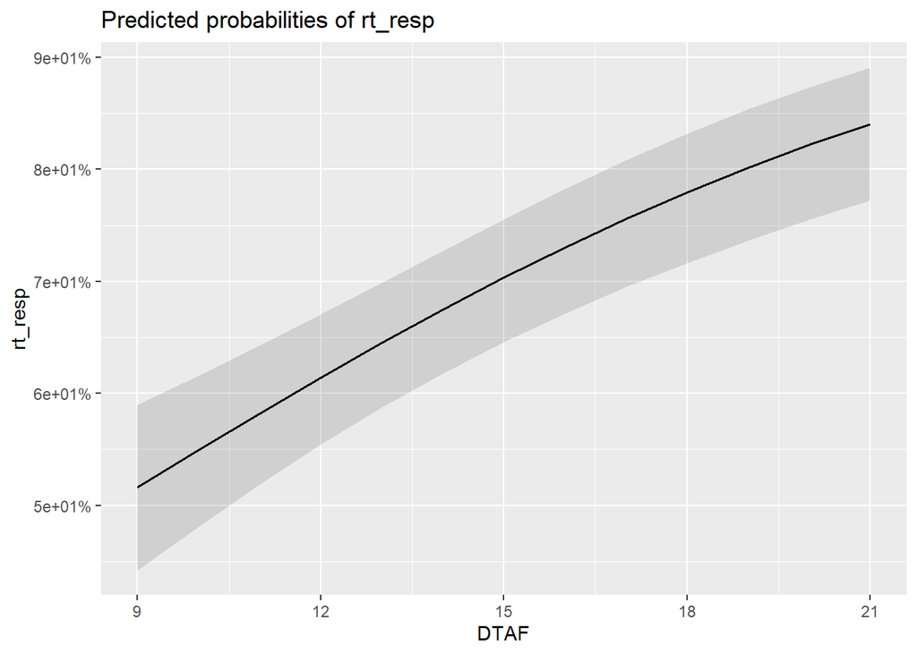

[output not shown]

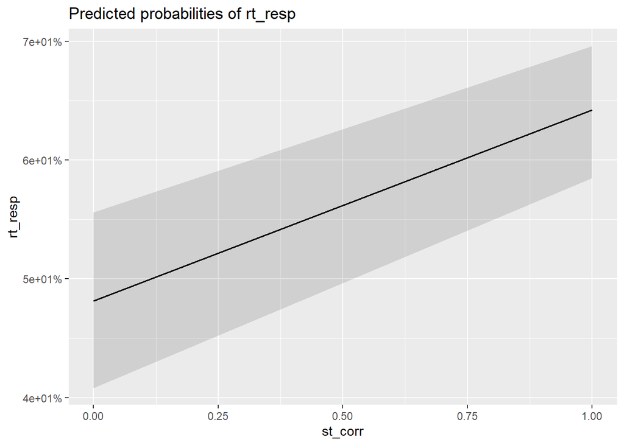

```
## Data were 'prettified'. Consider using `terms="DTAF [all]"` to get smooth plots.
```

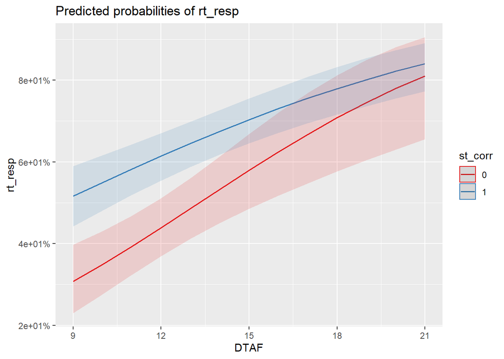

```
## Generalized linear mixed model fit by maximum likelihood (Laplace
##   Approximation) [glmerMod]
##  Family: binomial  ( logit )
## Formula: rt_resp ~ DTAN * st_corr + (1 | workerId)
##    Data: t2lmm
##
##      AIC      BIC   logLik deviance df.resid
##   2166.8   2194.1  -1078.4   2156.8     1729
##
## Scaled residuals:
##     Min      1Q  Median      3Q     Max
## -3.0066 -0.9508  0.4948  0.7590  2.3384
##
## Random effects:
##  Groups   Name        Variance Std.Dev.
##  workerId (Intercept) 0.469    0.6849
## Number of obs: 1734, groups:  workerId, 41
##
## Fixed effects:
##              Estimate Std. Error z value Pr(>|z|)
## (Intercept)  -3.32818    0.73917  -4.503 6.71e-06 ***
## DTAN          0.25209    0.05856   4.305 1.67e-05 ***
## st_corr       1.52917    0.85564   1.787   0.0739 .
## DTAN:st_corr -0.06613    0.06785  -0.975   0.3298
## ---
## Signif. codes:  0 '***' 0.001 '**' 0.01 '*' 0.05 '.' 0.1 ' ' 1
##
## Correlation of Fixed Effects:
##             (Intr) DTAN   st_crr
## DTAN        -0.980
## st_corr     -0.847  0.846
## DTAN:st_crr  0.846 -0.863 -0.990
```

[output not shown]

```
## Data were 'prettified'. Consider using `terms="DTAN [all]"` to get smooth plots.
```

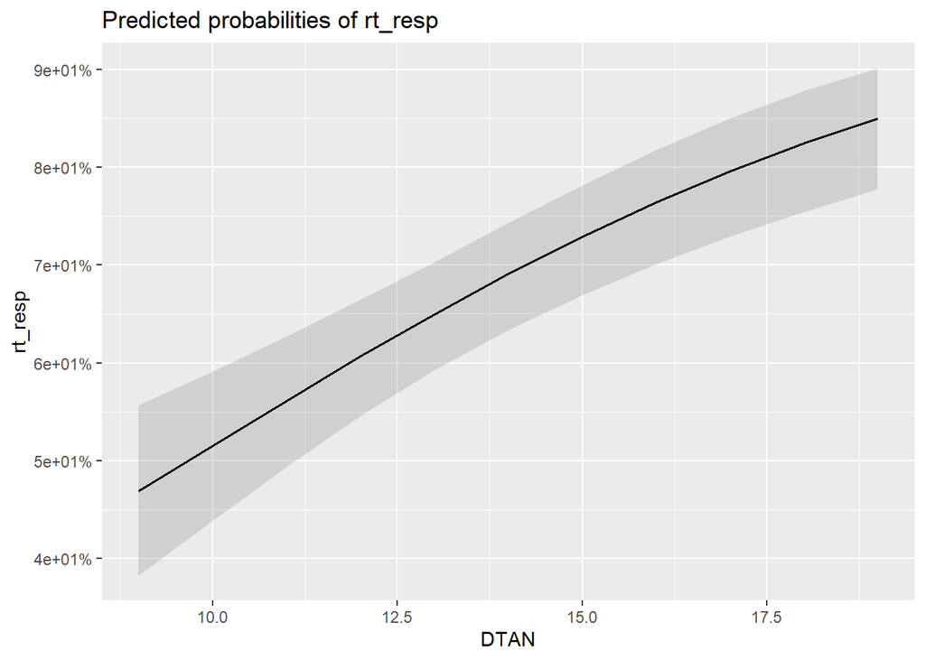

[output not shown]

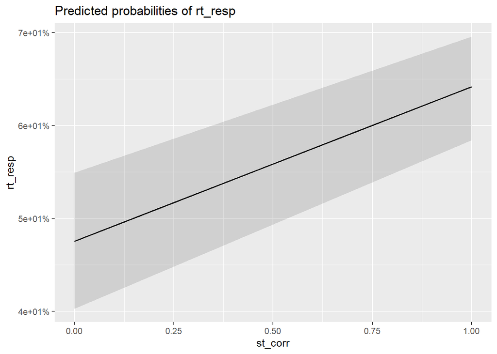

```
## Data were 'prettified'. Consider using `terms="DTAN [all]"` to get smooth plots.
```

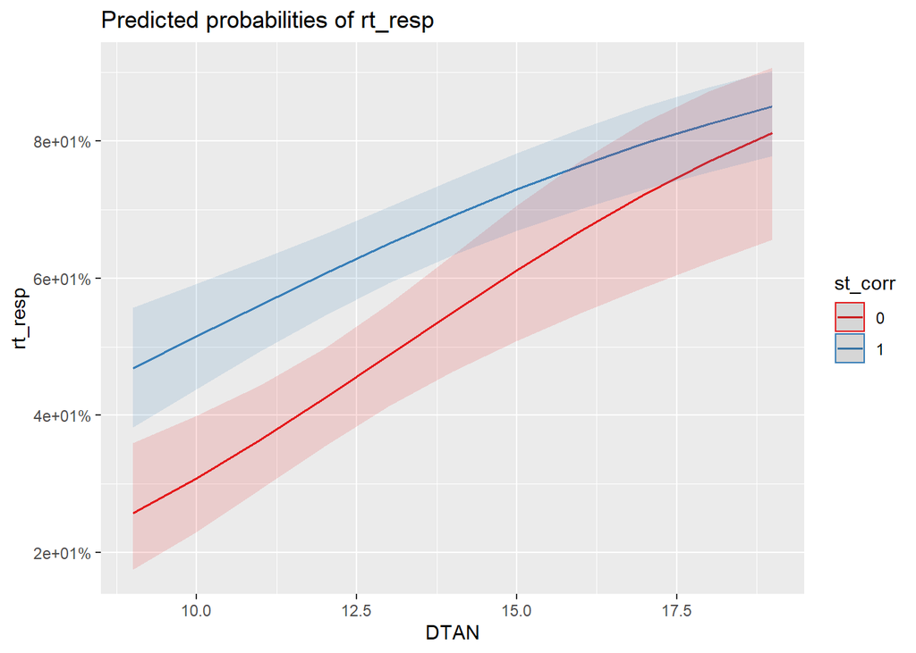

```
## Generalized linear mixed model fit by maximum likelihood (Laplace
##   Approximation) [glmerMod]
##  Family: binomial  ( logit )
## Formula: rt_resp ~ DTN_byPhase * st_corr + (1 | workerId)
##    Data: t2lmm
##
##      AIC      BIC   logLik deviance df.resid
##   2171.5   2198.8  -1080.8   2161.5     1729
##
## Scaled residuals:
##     Min      1Q  Median      3Q     Max
## -2.8337 -0.9538  0.5038  0.7594  2.3668
##
## Random effects:
##  Groups   Name        Variance Std.Dev.
##  workerId (Intercept) 0.4666   0.6831
## Number of obs: 1734, groups:  workerId, 41
##
## Fixed effects:
##                     Estimate Std. Error z value Pr(>|z|)
## (Intercept)         -3.28266    0.74918  -4.382 1.18e-05 ***
## DTN_byPhase          0.23992    0.05733   4.185 2.86e-05 ***
## st_corr              1.53572    0.87159   1.762   0.0781 .
## DTN_byPhase:st_corr -0.06433    0.06672  -0.964   0.3349
## ---
## Signif. codes:  0 '***' 0.001 '**' 0.01 '*' 0.05 '.' 0.1 ' ' 1
##
## Correlation of Fixed Effects:
##             (Intr) DTN_bP st_crr
## DTN_byPhase -0.980
## st_corr     -0.843  0.843
## DTN_byPhs:_  0.843 -0.860 -0.990
```

[output not shown]

```
## Data were 'prettified'. Consider using `terms="DTN_byPhase [all]"` to get smooth plots.
```

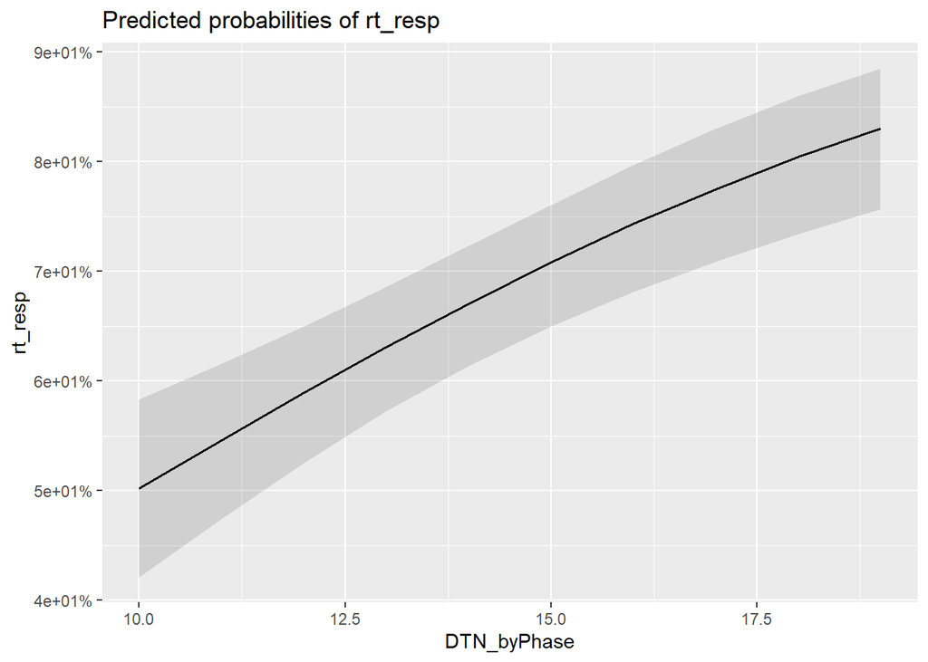

[output not shown]

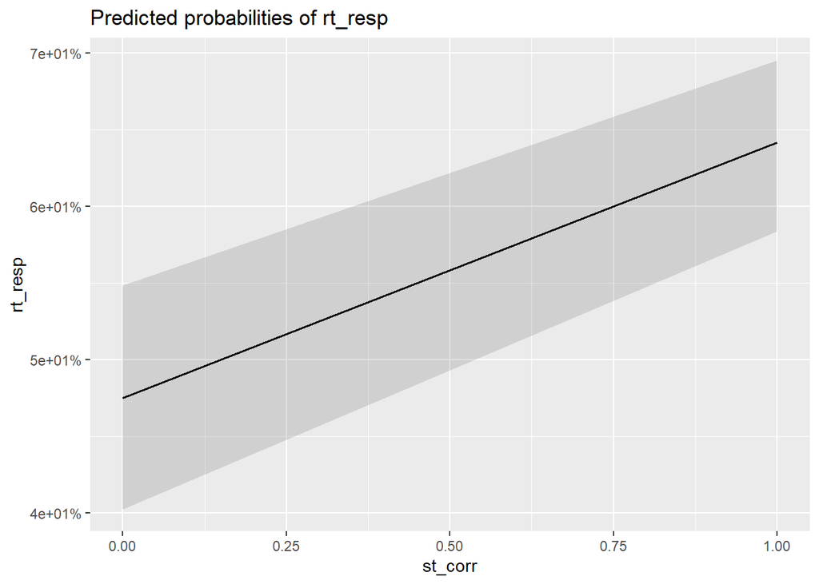

```
## Data were 'prettified'. Consider using `terms="DTN_byPhase [all]"` to get smooth plots.
```

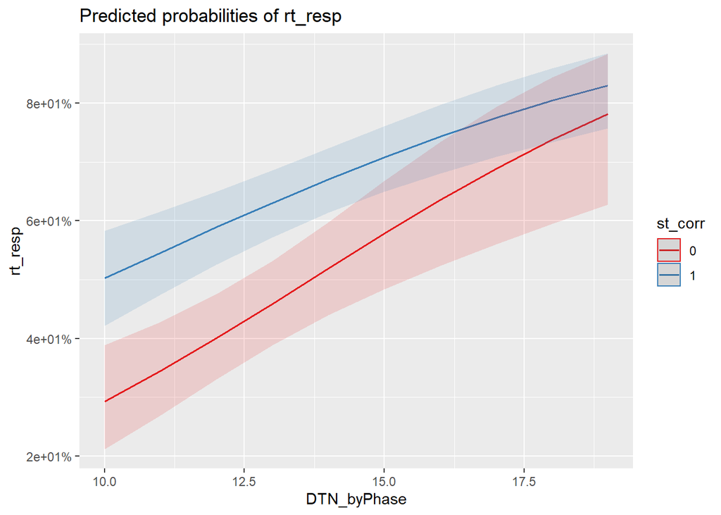

```
## Generalized linear mixed model fit by maximum likelihood (Laplace
##   Approximation) [glmerMod]
##  Family: binomial  ( logit )
## Formula: rt_resp ~ st_DTPPm * rt_DTPPm * st_corr + (1 | workerId)
##    Data: t2lmm
##
##      AIC      BIC   logLik deviance df.resid
##   2127.4   2176.5  -1054.7   2109.4     1725
##
## Scaled residuals:
##     Min      1Q  Median      3Q     Max
## -4.7889 -0.9069  0.4582  0.7490  3.5160
##
## Random effects:
##  Groups   Name        Variance Std.Dev.
##  workerId (Intercept) 0.486    0.6971
## Number of obs: 1734, groups:  workerId, 41
##
## Fixed effects:
##                           Estimate Std. Error z value Pr(>|z|)
## (Intercept)               -0.03618    4.57469  -0.008   0.9937
## st_DTPPm                  -1.05476    0.36337  -2.903   0.0037 **
## rt_DTPPm                   0.67490    0.39444   1.711   0.0871 .
## st_corr                   -1.92492    5.11490  -0.376   0.7067
## st_DTPPm:rt_DTPPm          0.02533    0.02234   1.134   0.2569
## st_DTPPm:st_corr           0.55159    0.41419   1.332   0.1830
## rt_DTPPm:st_corr          -0.05770    0.44377  -0.130   0.8966
## st_DTPPm:rt_DTPPm:st_corr -0.02107    0.02475  -0.852   0.3945
## ---
## Signif. codes:  0 '***' 0.001 '**' 0.01 '*' 0.05 '.' 0.1 ' ' 1
##
## Correlation of Fixed Effects:
##               (Intr) st_DTPP rt_DTPP st_crr st_DTPP:_DTPP st_DTPP:_ r_DTPP:
## st_DTPPm      -0.799
## rt_DTPPm      -0.890  0.447
## st_corr       -0.893  0.715   0.795
## st_DTPP:_DTPP  0.981 -0.858  -0.836  -0.876
## st_DTPPm:s_    0.701 -0.878  -0.391  -0.784  0.752
## rt_DTPPm:s_    0.791 -0.397  -0.888  -0.877  0.742         0.399
## s_DTPP:_DTPP: -0.884  0.775   0.753   0.980 -0.902        -0.847    -0.819
## convergence code: 0
## Model failed to converge with max|grad| = 0.0621067 (tol = 0.002, component 1)
## Model is nearly unidentifiable: very large eigenvalue
##  - Rescale variables?
## Model is nearly unidentifiable: large eigenvalue ratio
##  - Rescale variables?
```

[output not shown]

```
## Data were 'prettified'. Consider using `terms="st_DTPPm [all]"` to get smooth plots.
```

```
## Data were 'prettified'. Consider using `terms="rt_DTPPm [all]"` to get smooth plots.
```

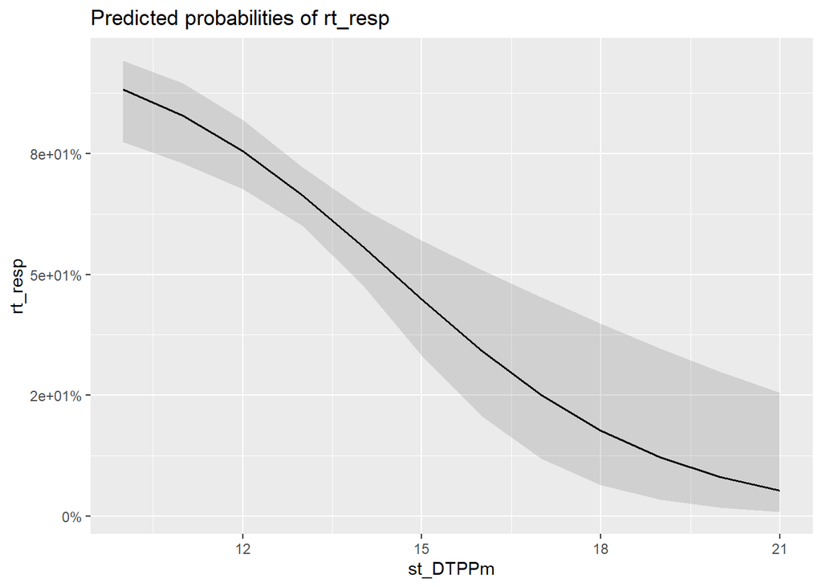

[output not shown]

```
## Data were 'prettified'. Consider using `terms="st_DTPPm [all]"` to get smooth plots.
```

```
## Data were 'prettified'. Consider using `terms="rt_DTPPm [all]"` to get smooth plots.
```

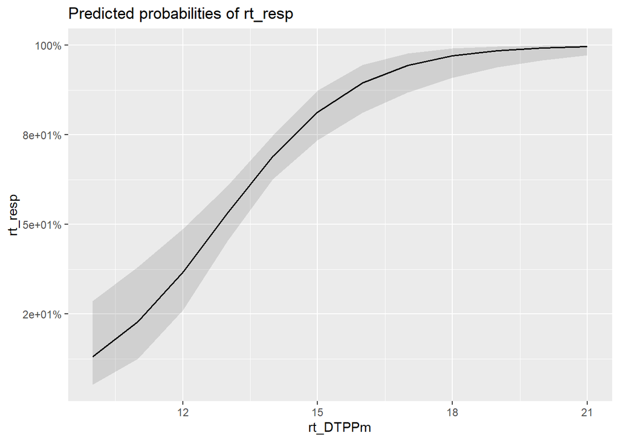

[output not shown]

```
## Data were 'prettified'. Consider using `terms="st_DTPPm [all]"` to get smooth plots.
```

```
## Data were 'prettified'. Consider using `terms="rt_DTPPm [all]"` to get smooth plots.
```

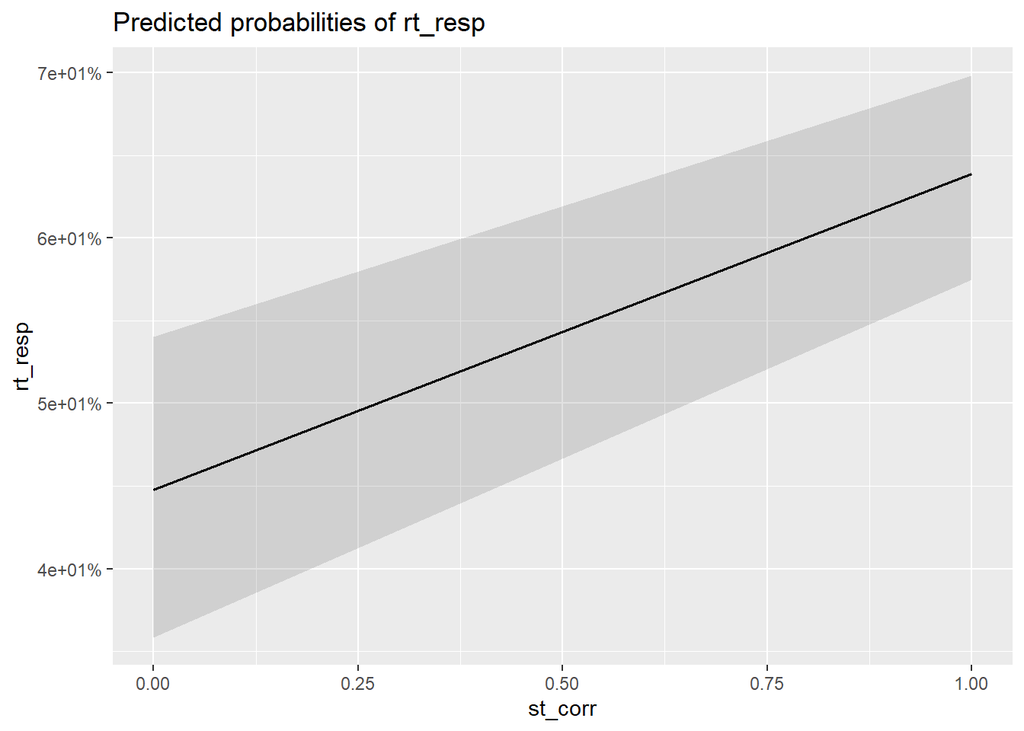

```
## Data were 'prettified'. Consider using `terms="st_DTPPm [all]"` to get smooth plots.
```

```
## Data were 'prettified'. Consider using `terms="st_DTPPm [all]"` to get smooth plots.
```

```
## Data were 'prettified'. Consider using `terms="rt_DTPPm [all]"` to get smooth plots.
```

```
## Data were 'prettified'. Consider using `terms="st_DTPPm [all]"` to get smooth plots.
```

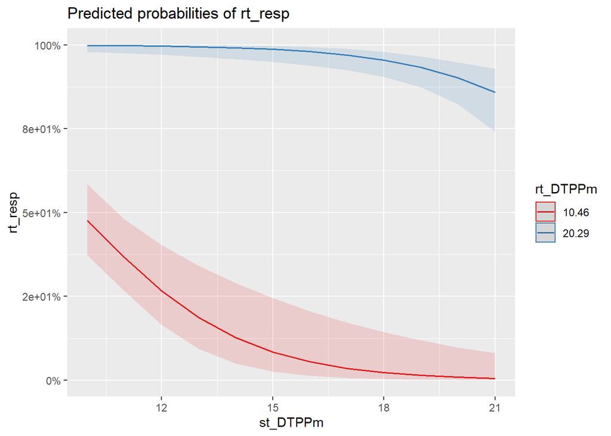

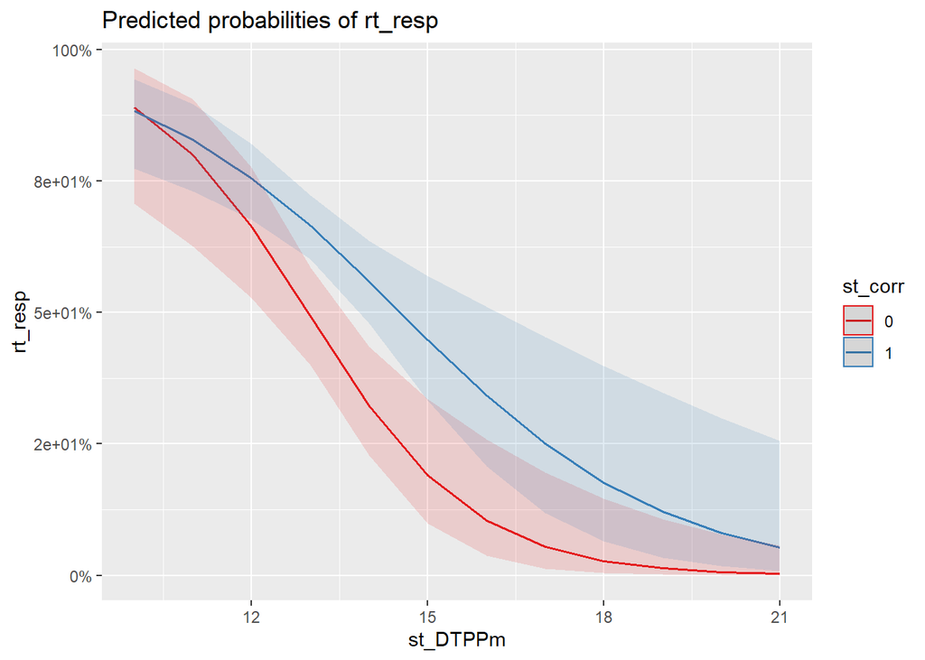

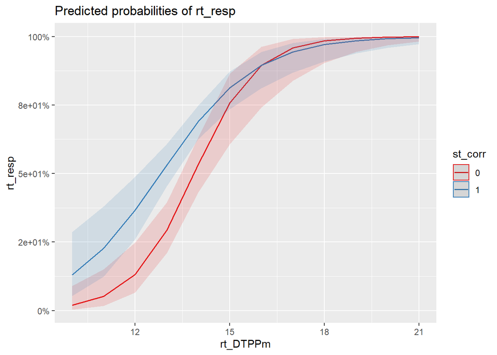

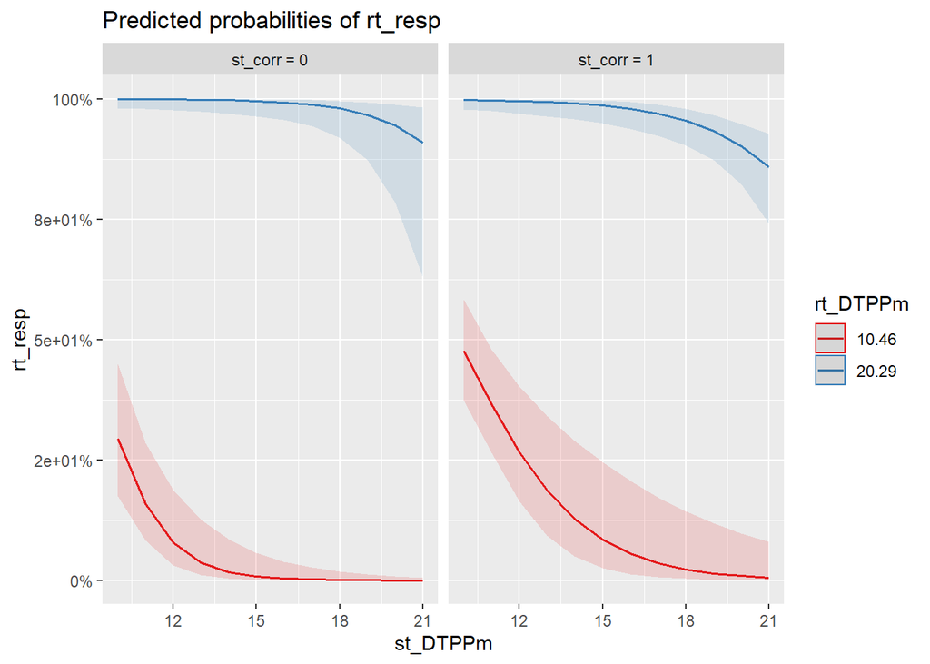

|  | rt_resp |  |  |  | rt_resp |  |  |  | rt_resp |  |  |  | rt_resp |  |  |  | rt_resp |  |  |  | rt_resp |  |  |  |
| --- | --- | --- | --- | --- | --- | --- | --- | --- | --- | --- | --- | --- | --- | --- | --- | --- | --- | --- | --- | --- | --- | --- | --- | --- |
| Predictors | Log-Odds | std. Error | CI | p | Log-Odds | std. Error | CI | p | Log-Odds | std. Error | CI | p | Log-Odds | std. Error | CI | p | Log-Odds | std. Error | CI | p | Log-Odds | std. Error | CI | p |
| (Intercept) | 1.20 | 0.35 | 0.52 – 1.88 | **0.001** | -0.99 | 0.21 | -1.40 – -0.59 | **<0.001** | -2.51 | 0.55 | -3.59 – -1.43 | **<0.001** | -3.33 | 0.74 | -4.78 – -1.88 | **<0.001** | -3.28 | 0.75 | -4.75 – -1.81 | **<0.001** | -0.04 | 4.57 | -9.00 – 8.93 | 0.994 |
| type [sarr] | -0.96 | 0.39 | -1.72 – -0.20 | **0.013** |  |  |  |  |  |  |  |  |  |  |  |  |  |  |  |  |  |  |  |  |
| type [sarrcol] | -1.33 | 0.39 | -2.10 – -0.56 | **0.001** |  |  |  |  |  |  |  |  |  |  |  |  |  |  |  |  |  |  |  |  |
| type [sarrsha] | -2.31 | 0.39 | -3.07 – -1.55 | **<0.001** |  |  |  |  |  |  |  |  |  |  |  |  |  |  |  |  |  |  |  |  |
| type [sarrshacol] | -1.56 | 0.40 | -2.35 – -0.77 | **<0.001** |  |  |  |  |  |  |  |  |  |  |  |  |  |  |  |  |  |  |  |  |
| st_corr | -0.00 | 0.36 | -0.70 – 0.70 | 0.997 | 1.15 | 0.21 | 0.75 – 1.55 | **<0.001** | 1.38 | 0.62 | 0.17 – 2.59 | **0.025** | 1.53 | 0.86 | -0.15 – 3.21 | 0.074 | 1.54 | 0.87 | -0.17 – 3.24 | 0.078 | -1.92 | 5.11 | -11.95 – 8.10 | 0.707 |
| type [sarr] * st_corr | 0.57 | 0.44 | -0.29 – 1.43 | 0.192 |  |  |  |  |  |  |  |  |  |  |  |  |  |  |  |  |  |  |  |  |
| type [sarrcol] * st_corr | 0.58 | 0.44 | -0.28 – 1.44 | 0.183 |  |  |  |  |  |  |  |  |  |  |  |  |  |  |  |  |  |  |  |  |
| type [sarrsha] * st_corr | 1.42 | 0.44 | 0.56 – 2.28 | **0.001** |  |  |  |  |  |  |  |  |  |  |  |  |  |  |  |  |  |  |  |  |
| type [sarrshacol] * st_corr | 0.55 | 0.45 | -0.33 – 1.42 | 0.221 |  |  |  |  |  |  |  |  |  |  |  |  |  |  |  |  |  |  |  |  |
| DTF |  |  |  |  | 0.14 | 0.03 | 0.09 – 0.19 | **<0.001** |  |  |  |  |  |  |  |  |  |  |  |  |  |  |  |  |
| DTF * st_corr |  |  |  |  | -0.08 | 0.03 | -0.14 – -0.02 | **0.008** |  |  |  |  |  |  |  |  |  |  |  |  |  |  |  |  |
| DTAF |  |  |  |  |  |  |  |  | 0.19 | 0.04 | 0.10 – 0.27 | **<0.001** |  |  |  |  |  |  |  |  |  |  |  |  |
| DTAF * st_corr |  |  |  |  |  |  |  |  | -0.06 | 0.05 | -0.15 – 0.04 | 0.257 |  |  |  |  |  |  |  |  |  |  |  |  |
| DTAN |  |  |  |  |  |  |  |  |  |  |  |  | 0.25 | 0.06 | 0.14 – 0.37 | **<0.001** |  |  |  |  |  |  |  |  |
| DTAN * st_corr |  |  |  |  |  |  |  |  |  |  |  |  | -0.07 | 0.07 | -0.20 – 0.07 | 0.330 |  |  |  |  |  |  |  |  |
| DTN_byPhase |  |  |  |  |  |  |  |  |  |  |  |  |  |  |  |  | 0.24 | 0.06 | 0.13 – 0.35 | **<0.001** |  |  |  |  |
| DTN_byPhase * st_corr |  |  |  |  |  |  |  |  |  |  |  |  |  |  |  |  | -0.06 | 0.07 | -0.20 – 0.07 | 0.335 |  |  |  |  |
| st_DTPPm |  |  |  |  |  |  |  |  |  |  |  |  |  |  |  |  |  |  |  |  | -1.05 | 0.36 | -1.77 – -0.34 | **0.004** |
| rt_DTPPm |  |  |  |  |  |  |  |  |  |  |  |  |  |  |  |  |  |  |  |  | 0.67 | 0.39 | -0.10 – 1.45 | 0.087 |
| st_DTPPm * rt_DTPPm |  |  |  |  |  |  |  |  |  |  |  |  |  |  |  |  |  |  |  |  | 0.03 | 0.02 | -0.02 – 0.07 | 0.257 |
| st_DTPPm * st_corr |  |  |  |  |  |  |  |  |  |  |  |  |  |  |  |  |  |  |  |  | 0.55 | 0.41 | -0.26 – 1.36 | 0.183 |
| rt_DTPPm * st_corr |  |  |  |  |  |  |  |  |  |  |  |  |  |  |  |  |  |  |  |  | -0.06 | 0.44 | -0.93 – 0.81 | 0.897 |
| (st_DTPPm * rt_DTPPm) * st_corr |  |  |  |  |  |  |  |  |  |  |  |  |  |  |  |  |  |  |  |  | -0.02 | 0.02 | -0.07 – 0.03 | 0.394 |
| Random Effects |  |  |  |  |  |  |  |  |  |  |  |  |  |  |  |  |  |  |  |  |  |  |  |  |
| σ<sup>2</sup> | 3.29 |  |  |  | 3.29 |  |  |  | 3.29 |  |  |  | 3.29 |  |  |  | 3.29 |  |  |  | 3.29 |  |  |  |
| τ<sub>00</sub> | 0.50 <sub>workerId</sub> |  |  |  | 0.48 <sub>workerId</sub> |  |  |  | 0.47 <sub>workerId</sub> |  |  |  | 0.47 <sub>workerId</sub> |  |  |  | 0.47 <sub>workerId</sub> |  |  |  | 0.49 <sub>workerId</sub> |  |  |  |
| ICC | 0.13 |  |  |  | 0.13 |  |  |  | 0.12 |  |  |  | 0.12 |  |  |  | 0.12 |  |  |  | 0.13 |  |  |  |
| N | 41 <sub>workerId</sub> |  |  |  | 41 <sub>workerId</sub> |  |  |  | 41 <sub>workerId</sub> |  |  |  | 41 <sub>workerId</sub> |  |  |  | 41 <sub>workerId</sub> |  |  |  | 41 <sub>workerId</sub> |  |  |  |
| Observations | 1734 |  |  |  | 1734 |  |  |  | 1734 |  |  |  | 1734 |  |  |  | 1734 |  |  |  | 1734 |  |  |  |
| Marginal R<sup>2</sup> / Conditional R<sup>2</sup> | 0.092 / 0.212 |  |  |  | 0.080 / 0.197 |  |  |  | 0.076 / 0.191 |  |  |  | 0.070 / 0.186 |  |  |  | 0.066 / 0.182 |  |  |  | 0.106 / 0.221 |  |  |  |
| AIC | 2147.024 |  |  |  | 2154.652 |  |  |  | 2160.002 |  |  |  | 2166.862 |  |  |  | 2171.538 |  |  |  | 2127.457 |  |  |  |

The difference in correct recognitions and correct rejections between categories is due to the fact that they are more or less similar to the prototypes (thus this may be the effect of the familiarization phase which we also saw in the study phase).

During the task the participants generate predictions as to what happens next (not due to the instructions but automatically). Those stimuli that are most different from most of the stimuli should be remembered better.

By calculating a the number of correct recognitions (old - seen) and correct rejections (new - not seen) and correcting these numbers with the respective false alarm rates (new - seen; old - not seen) and adding these we get a number that reflects how well the participants distinguished pictures in the test phase. These numbers are very low (below 5 which translates to a rating of about 0.25 - the corrected rate of correct categorizations - max would be 20 for a category), which suggests that the task was hard. Yet there are differences in this number between the categories which shows that some categories were more likely to be correctly categorized. We would expect that diffarf would be the highest, while sharrshacol the lowest, with a gradual decrease through the other categories. This is partly supported by the data, but the experiment should be repeated with an easier stimulus set.